# Between-Sample (Beta) Diversity of Microbes along a Salinity Gradient

# 3. Scale Read Counts

```r
min(sample_sums(midpoint_rooted_physeq))
```

```
## [1] 24199
```

```r
# Scale the reads
scaled_physeq <-
  midpoint_rooted_physeq %>%
  scale_reads(round = "matround")

# Look at it
scaled_physeq
```

```
## phyloseq-class experiment-level object
## otu_table()   OTU Table:         [ 2114 taxa and 19 samples ]
## sample_data() Sample Data:       [ 19 samples by 40 sample variables ]
## tax_table()   Taxonomy Table:    [ 2114 taxa by 9 taxonomic ranks ]
## phy_tree()    Phylogenetic Tree: [ 2114 tips and 2113 internal nodes ]
```

```r
save(scaled_physeq, file = "data/06_Ordination/scaled_physeq.RData")

# Look at it more!
#View(data.frame(otu_table(archaeal_rooted_physeq)))
#View(data.frame(otu_table(scaled_physeq)))

# Confirm seq read depth of scaled_physeq
scaled_TotalSeqs_df <-
  scaled_physeq %>%
  sample_sums() %>%
  data.frame()

colnames(scaled_TotalSeqs_df)[1] <- "TotalSeqs"

# add a new column of num_ASVs (RAW, non-noramlized # ASVs)
scaled_TotalSeqsASVs_df <-
  scaled_TotalSeqs_df %>%
  mutate(num_ASVs = colSums(otu_table(scaled_physeq) > 1))

# Plot it!
scaledSeq_histogram <-
  scaled_TotalSeqs_df %>%
  ggplot(aes(x = TotalSeqs)) +
  geom_histogram(bins = 50) +
  labs(title = "Scaled Seq Depth Histogram") +
  scale_x_continuous(limits = c(0, 60000)) +
  theme_bw()

# Scaling always gives us a range!
# MInimum sequences
min(scaled_TotalSeqs_df$TotalSeqs)
```

```
## [1] 24183
```

```r
# Total Range
range(scaled_TotalSeqs_df)
```

```
## [1] 24183 24226
```

```r
# How many is that range?
range_seqs <- (max(scaled_TotalSeqs_df$TotalSeqs) - min(scaled_TotalSeqs_df$TotalSeqs))
range_seqs
```

```
## [1] 43
```

```r
# And in terms of percent?
range_seqs/max(scaled_TotalSeqs_df$TotalSeqs)
```

```
## [1] 0.001774953
```

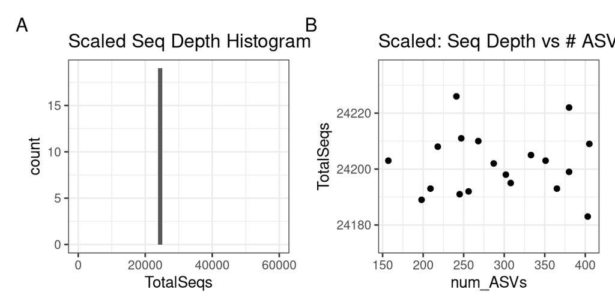

```r
#View(scaled_TotalSeqs_df)

# Set the axis min and max for the next plot
max_y <- max(scaled_TotalSeqs_df$TotalSeqs) + 10
min_y <- min(scaled_TotalSeqs_df$TotalSeqs) - 10

# Now, draw the plot
scaledSeq_vs_numASV_plot <-
  scaled_TotalSeqsASVs_df %>%
  ggplot(aes(x = num_ASVs, y = TotalSeqs)) +
  geom_point() +
  scale_y_continuous(limits = c(min_y, max_y)) +
  #geom_smooth(method = "lm") +
  theme_bw() +
  labs(title = "Scaled: Seq Depth vs # ASVs")

# Put the two plots together.
scaledSeq_histogram + scaledSeq_vs_numASV_plot +
  plot_annotation(tag_levels = "A")
```

**INTERPRETATION #3: Evaluate the scaled read count plots above. Are the total number of sequences across all of your samples in the same general range? What is the minimum and maximum (i.e., the range) of the sequencing depth? How was the relationship with the number of ASVs modified after scaling the read counts?**

- Yes. Panel A shows a histogram of total sequences, and all bars are stacked at a single value, indicating that each sample has almost the exact same sequencing depth after scaling.
- The minimum sequencing depth is 24183, and the maximum sequencing depth is 24226. The range of the sequencing depth is 43.
- In Panel B, despite having nearly identical sequencing depths, the number of ASVs still varies widely across samples from 150 to 400. The variation in ASV richness is not simply due to sequencing depth. Scaling removed depth as a confounding factor, so the observed differences in ASV counts reflect true biological differences in richness across samples.

# Beta Diversity: Dissimilarity Metrics in Microbial Ecology

## Similarity versus Dissimilarity

## Common dissimilarity measures

## Five Types of Dissimilarities

### B. Sorensen-Dice Dissimilarity

### C. Bray-Curtis Dissimilarity

### D. Unweighted UniFrac Dissimilarity

### E. Weighted UniFrac Dissimilarity

# 4. Calculating dissimilarity

Now, let’s make distance objects of each of the dissimiliarity measures above!

```r
# Sorensen Dissimiliarty
scaled_sorensen_dist <- phyloseq::distance(scaled_physeq, method = "bray", binary = TRUE)

# What does it look like?
class(scaled_sorensen_dist)
```

```
## [1] "dist"
```

```r
str(scaled_sorensen_dist)
```

```
##  'dist' num [1:171] 0.608 0.492 0.78 0.825 0.702 ...
##  - attr(*, "maxdist")= num 1
##  - attr(*, "Size")= int 19
##  - attr(*, "Labels")= chr [1:19] "SRR12873300" "SRR12873301" "SRR12873302" "SRR12873303" ...
##  - attr(*, "Diag")= logi FALSE
##  - attr(*, "Upper")= logi FALSE
##  - attr(*, "method")= chr "binary bray"
##  - attr(*, "call")= language vegdist(x = c(0, 0, 0, 0, 16, 0, 24, 16, 21, 0, 40, 0, 19, 0, 16, 0, 26,  27, 141, 0, 0, 0, 0, 0, 0, 0, 10, 0, 0,| __truncated__ ...
```

```r
#head(as.matrix(scaled_sorensen_dist))

# Bray-Curtis Dissimiliarty
scaled_bray_dist <- phyloseq::distance(scaled_physeq, method = "bray", binary = FALSE)

# Abundance-Unweighted UniFrac
scaled_uUnifrac_dist <- phyloseq::distance(scaled_physeq, method = "unifrac")

# Abundance-Weighted UniFrac
scaled_wUnifrac_dist <- phyloseq::distance(scaled_physeq, method = "wunifrac")
```

**INTERPRETATION #4: Which dissimilarity metric is most related to your scientific question? Why or why not?**